# Disclaimer

This notebook was created for the SAV block course "Deep Learning with Actuarial Applications in R".

The course is based on the publications on the following website: https://www.actuarialdatascience.org/

Author: Daniel Meier

# Applying Convolutional Neural Networks for image classification

Inception v3 is one of the pre-trained neural networks available in the keras library. Developed by Google, Inception v3 has 23'851'784 parameters, uses 299x299x3 color images as inputs, and has 1'000 image classes, e.g. baseketball, violin, ear, etc.

## 0. Load the model, classes, define functions

```python
import tensorflow as tf
import json

path_to_files = 'data/cnn3/'
model = tf.keras.applications.InceptionV3(
    include_top=True,
    weights= path_to_files + 'inception_v3_weights_tf_dim_ordering_tf_kernels.h5',
    input_tensor=None,
    input_shape=None,
    pooling=None,
    classes=1000
)

with open(path_to_files + 'imagenet_class_index.json') as file:
    classes = json.load(file)
```

Number of layers of Inception v3:

```python
len(model.layers)
```

```
313
```

The complete structure of Inception v3 is quite involved...

```python
model.summary()
```

```
Model: "inception_v3"
__________________________________________________________________________________________________
Layer (type)                    Output Shape         Param #     Connected to
==================================================================================================
input_1 (InputLayer)            [(None, 299, 299, 3) 0
__________________________________________________________________________________________________
conv2d (Conv2D)                 (None, 149, 149, 32) 864         input_1[0][0]
__________________________________________________________________________________________________
batch_normalization (BatchNorma (None, 149, 149, 32) 96          conv2d[0][0]
__________________________________________________________________________________________________
activation (Activation)         (None, 149, 149, 32) 0           batch_normalization[0][0]
__________________________________________________________________________________________________
conv2d_1 (Conv2D)               (None, 147, 147, 32) 9216        activation[0][0]
__________________________________________________________________________________________________
batch_normalization_1 (BatchNor (None, 147, 147, 32) 96          conv2d_1[0][0]
__________________________________________________________________________________________________
activation_1 (Activation)       (None, 147, 147, 32) 0           batch_normalization_1[0][0]
__________________________________________________________________________________________________
conv2d_2 (Conv2D)               (None, 147, 147, 64) 18432       activation_1[0][0]
__________________________________________________________________________________________________
batch_normalization_2 (BatchNor (None, 147, 147, 64) 192         conv2d_2[0][0]
__________________________________________________________________________________________________
activation_2 (Activation)       (None, 147, 147, 64) 0           batch_normalization_2[0][0]
__________________________________________________________________________________________________
max_pooling2d (MaxPooling2D)    (None, 73, 73, 64)   0           activation_2[0][0]
__________________________________________________________________________________________________
conv2d_3 (Conv2D)               (None, 73, 73, 80)   5120        max_pooling2d[0][0]
__________________________________________________________________________________________________
batch_normalization_3 (BatchNor (None, 73, 73, 80)   240         conv2d_3[0][0]
__________________________________________________________________________________________________
activation_3 (Activation)       (None, 73, 73, 80)   0           batch_normalization_3[0][0]
__________________________________________________________________________________________________
conv2d_4 (Conv2D)               (None, 71, 71, 192)  138240      activation_3[0][0]
__________________________________________________________________________________________________
batch_normalization_4 (BatchNor (None, 71, 71, 192)  576         conv2d_4[0][0]
__________________________________________________________________________________________________
activation_4 (Activation)       (None, 71, 71, 192)  0           batch_normalization_4[0][0]
__________________________________________________________________________________________________
max_pooling2d_1 (MaxPooling2D)  (None, 35, 35, 192)  0           activation_4[0][0]
__________________________________________________________________________________________________
```

[output cut: 614 more lines]

```
activation_93 (Activation)      (None, 8, 8, 192)    0           batch_normalization_93[0][0]
__________________________________________________________________________________________________
mixed10 (Concatenate)           (None, 8, 8, 2048)   0           activation_85[0][0]
                                                                 mixed9_1[0][0]
                                                                 concatenate_1[0][0]
                                                                 activation_93[0][0]
__________________________________________________________________________________________________
avg_pool (GlobalAveragePooling2 (None, 2048)         0           mixed10[0][0]
__________________________________________________________________________________________________
predictions (Dense)             (None, 1000)         2049000     avg_pool[0][0]
==================================================================================================
Total params: 23,851,784
Trainable params: 23,817,352
Non-trainable params: 34,432
__________________________________________________________________________________________________
```

1'000 image classes:

```python
print([x[1] for x in classes.values()])
```

```
['tench', 'goldfish', 'great_white_shark', 'tiger_shark', 'hammerhead', 'electric_ray', 'stingray', 'cock', 'hen', 'ostrich', 'brambling', 'goldfinch', 'house_finch', 'junco', 'indigo_bunting', 'robin', 'bulbul', 'jay', 'magpie', 'chickadee', 'water_ouzel', 'kite', 'bald_eagle', 'vulture', 'great_gr…
```

The function `predict` returns the full 1'000 dimensional output vector of a 299x299x3 input image.

```python
import numpy as np
from keras.preprocessing import image
from keras.applications.inception_v3 import preprocess_input

def predict(model, img, target_size=(299, 299)):
    x = image.img_to_array(img)
    x = np.expand_dims(x, axis=0)
    x = preprocess_input(x)
    pred = model.predict(x)
    return pred
```

In the following we will be using 2 methods to obtain a 299x299x3 array/image, both methods can make use of a built-in camera if available.

- **Method 1:** Taking screenshots every 2 seconds and taking a 299x299 region from the screenshot as input. Note that you can use the parameters `x_shift` and `y_shift` to move this region. With the current setting the region should be located near the upper left corner of your screen.
- **Method 2:** In case a built-in camera is available, this method extracts a snapshot directly from the video stream. No calibration of parameters (`x_shift`, `y_shift`) needed.

```python
from PIL import Image
import base64
import io
import pyautogui, time
from IPython.display import clear_output
import matplotlib.pylab as plt

# getting the top 5 classes based on a 299x299x3 array/image
def get_classes(img):
    pred = predict(model, img)[0]
    idx = (-pred).argsort()[:5]
    msg = ''
    for i in idx:
        msg += (str(pred[i])+": "+classes[str(i)][1]+"\n")
    return msg

# getting the top 5 classes based on a PIL image
def get_classes_pil(pil_img):
    pil_img = Image.open(io.BytesIO(base64.b64decode(pil_img.split(',')[1])))
    img = np.array(pil_img)
    img = img[:,:,0:3]
    return get_classes(img)
```

# Method 1

First, calibrate parameters x_shift and y_shift such that e.g. the video stream is captured. Then, in order to stop the loop hit **interrupt kernel**.

**Exercise:** Calibrate `x_shift` and `y_shift` parameters. Uncomment the `#break` line to obtain a plot of the captured region. Then you can also try to find some images on google and put them over the captured region to get them classified...

```python
from IPython.display import HTML

HTML("""
<video id="video" width="400" height="300" autoplay></video>
<canvas id="canvas" width="299" height="299"></canvas>
<script>
var video = document.getElementById('video');
if(navigator.mediaDevices && navigator.mediaDevices.getUserMedia) {
    navigator.mediaDevices.getUserMedia({ video: true }).then(function(stream) {
        video.srcObject=stream;
        video.play();
    });
}
</script>
""")
```

[video not shown]

```
0.5830279: cellular_telephone
0.14899388: hand-held_computer
0.07142413: iPod
0.01413632: hard_disc
0.012719685: remote_control
```

```
---------------------------------------------------------------------------
KeyboardInterrupt                         Traceback (most recent call last)
<ipython-input-8-a10034fb6151> in <module>
      8     print(get_classes(img))
      9     plt.imshow(img)
---> 10     time.sleep(2)
     11     #break

KeyboardInterrupt:
```

[figure not shown]

```python
x_shift = 550
y_shift = 250
while True:
    pil_img = pyautogui.screenshot()
    img = np.array(pil_img)
    img = img[y_shift:y_shift+299,x_shift:x_shift+299,0:3]
    clear_output()
    print(get_classes(img))
    plt.imshow(img)
    time.sleep(2)
    #break
```

# Method 2

- First cell: extract image from video stream into img variable
- Second cell: print (top 5) predictions

```python
from IPython.display import Javascript, display
js = """
    var canvas = document.getElementById('canvas');
    var context = canvas.getContext('2d');
    var video = document.getElementById('video');
    context.drawImage(video, -50, 0, 400, 300);
    var myCanvas = document.getElementById('canvas');
    var image = myCanvas.toDataURL("image/png");
    IPython.notebook.kernel.execute("img = '" + image + "'")
    """
display(Javascript(js))
```

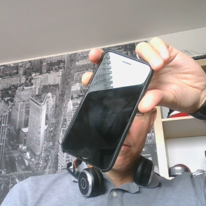

```
0.51721996: hand-held_computer
0.18662558: iPod
0.14468682: cellular_telephone
0.023642901: remote_control
0.012142319: hard_disc
```

```python
display(Image.open(io.BytesIO(base64.b64decode(img.split(',')[1]))))
print(get_classes_pil(img))
```